# QTLs and variability

Keisuke Atsumi

20/11/20 13:34

## Setup

### Load packages

```r
rm(list=ls())  # reset workspace
options(scipen=100)  # do not show numbers using exponential

# install & load packages
pacman::p_load(
  openxlsx   # open excel
  , tidyverse
  , magrittr   # extended pipe
  , metafor    # meta-analysis
  , MCMCglmm   # comparative analysis
  , orchaRd    # Orchard plot - meta-analysis
  , rotl       # open tree of life
  , ape        # Phylogeny
  , phytools   # Phylogeny
  , knitr
  , kableExtra # nice tables
  , pander     # nice tables
  , svglite    # Export SVG plots
  , ggiraphExtra # Geom predict
  # , R.rsp
)

# Rmarkdown settings
knitr::opts_chunk$set(
  prompt  = FALSE,  # Do not add > or + in inline-code
  message = FALSE,
  comment = "",
  warning = FALSE,  # Mute warnings
  tidy    = TRUE
  )
options(knitr.kable.NA = '') # Hide NAs in kable table
```

# Dataset

I searched QTL mapping studies through forward citations of primary studies. I could find QTLs only for 10 traits.  
Among those, all species pairs were male heterogametic, and both recciprocal hybrids were viable. Genetic distance metrics was not available for the crossin using *Laupara* crickets.

```r
## Phenotype data ##
pheno <- read.xlsx(
    "../data/original.data.xlsx", sheet = "Phenotype"
    # Same data is also saved as "../data/original.data.Phenotype.txt"
    ) %>%
  # Excluding data without any parent data
  drop_na(contains("SD.sp")) %>%
  # to numeric
  mutate_at(
    vars(contains("Mn") | contains("SD") | N.sp1:N.sp2),
    as.numeric
    ) %>%
  # delete observation with negative mean trait value
  filter(Mn.sp1 > 0 & Mn.sp2 > 0 & homologous == "Yes") %>%
  # calculate phenotypic difference between parental species
  mutate(
    Pheno.divergence = abs(log(Mn.sp1/Mn.sp2))
    ) %>%
  mutate_at(vars(contains("pheno.div")), scale) %>%
  # describe whether full cross or not
  mutate(
    Reciprocal = ifelse(
      is.na(Mn.hyb12 & Mn.hyb21),
      "Inviable", "Viable"
      )
    )

meta <- read.xlsx(
    "../data/original.data.xlsx", sheet = "Species.level.moderators"
    # Same data is also saved as "../data/original.data.Species.level.moderators.txt"
    ) %>%
  mutate_at(vars(contains("divergence")), as.numeric) %>%
  # Logalize genetic divergence
  mutate_at(vars(contains("divergence")), log10)


#++++++++++++++++++++++++++++++++++++++++++++++
# Combine phenotypic data and moderators data
#++++++++++++++++++++++++++++++++++++++++++++++
original.dat <- left_join(read.csv("QTL.csv"), pheno) %>%
  drop_na(N.QTL) %>%
  left_join(., meta)
# add unique ID for each effect size (row)
original.dat$ES.ID <- paste("ES", sprintf("%03d",c(1:dim(original.dat)[1])), sep="")


summary <- original.dat %>%
  group_by(taxa) %>%
  summarise(
    'Species pair' = length(unique(species.pair)),
    'Obser- vation' = length(unique(ES.ID)),
    Study = length(unique(Study.ID))
    )


### Table ###
original.dat %>%
  kable("html", digits = 3) %>%
  kable_styling("striped", position = "left") %>%
  scroll_box(width = "80%", height = "300px")
```

| w | Study.name | Source | Cross.ID | Genus | sp1.name | sp2.name | species.pair | trait.type | trait | QTL.study | N.QTL | Study.ID | homologous | Mn.sp1 | SD.sp1 | SE.sp1 | Mn.hyb12 | SD.hyb12 | SE.hyb12 | Mn.hyb21 | SD.hyb21 | SE.hyb21 | Mn.sp2 | SD.sp2 | SE.sp2 | Parents.sp1F.sp1 | Parents.sp1M.sp1 | Parents.sp1F.hyb12 | Parents.sp1M.hyb21 | … |
| --- | --- | --- | --- | --- | --- | --- | --- | --- | --- | --- | --- | --- | --- | --- | --- | --- | --- | --- | --- | --- | --- | --- | --- | --- | --- | --- | --- | --- | --- | --- |
| s001 | Blankers.et.al_2015 | table1 | Gryllus_rubens_Gryllus_texensis | Gryllus | Gryllus_rubens | Gryllus_texensis | Gryllus_rubens_Gryllus_texensis | sound | Carrier frequency | Blankers.2019.Evolution | 3 | s001 | Yes | 4.730 | 0.270 |  | 4.820 | 0.270 |  | 5.010 | 0.170 |  | 5.180 | 0.220 |  |  |  | 12 | 12 | … |
| s001 | Blankers.et.al_2015 | table1 | Gryllus_rubens_Gryllus_texensis | Gryllus | Gryllus_rubens | Gryllus_texensis | Gryllus_rubens_Gryllus_texensis | sound | Pulse rate | Blankers.2019.Evolution | 5 | s001 | Yes | 45.340 | 3.860 |  | 55.270 | 3.960 |  | 61.960 | 2.790 |  | 66.880 | 5.400 |  |  |  | 12 | 12 | … |
| s005 | Coyne_1985 | table1&2 | BGxOxnard | Drosophila | Drosophila_mauritiana | Drosophila_simulans | Drosophila_mauritiana_Drosophila_simulans | morphology | Sex comb tooth number | Graze.2007.Genetics; True.1997.Evolution | 1 | s005 | Yes | 14.310 | 1.131 | 0.080 | 12.330 | 1.015 | 0.100 | 12.100 | 0.990 | 0.070 | 9.860 | 0.849 | 0.060 |  |  |  |  | … |
| s008 | Coyne.et.al_1991 | table4 | pn_j_irX85 | Drosophila | Drosophila_mauritiana | Drosophila_sechellia | Drosophila_mauritiana_Drosophila_sechellia | morphology | Genital area | Tanaka.2015.Genetics | 3 | s008 | Yes | 1.746 | 0.210 | 0.035 | 3.323 | 0.450 | 0.074 | 3.104 | 0.371 | 0.061 | 5.311 | 0.523 | 0.086 |  |  |  |  | … |
| s12 | Ewing_1969 | table2 | Drosophila_persimilis_Drosophila_pseudoobscura | Drosophila | Drosophila_persimilis | Drosophila_pseudoobscura | Drosophila_persimilis_Drosophila_pseudoobscura | sound | Mean HRR song pulse intervals in msec | Williams.2001.Heredity | 3 | s12 | Yes | 66.800 | 10.900 |  | 48.700 | 7.900 |  | 56.800 | 7.300 |  | 42.600 | 4.800 |  |  |  | 25 | 25 | … |
| s17 | Magalhaes&Seehausen_2010 | Fig2 | Pundamilia_nyererei_Pundamilia_pundamilia | Pundamilia | Pundamilia_nyererei | Pundamilia_pundamilia | Pundamilia_nyererei_Pundamilia_pundamilia | morphology | % red cover of body | Feller.2020.ProcB | 4 | s17 | Yes | 26.227 | 8.335 |  | 6.875 | 6.019 |  | 7.100 | 5.122 |  | 2.450 | 1.658 |  |  |  | 4 | 4 | … |
| s22 | Shaw_1996 | table4 | KW L. paranigra | Laupala | Laupala_kohalensis | Laupala_paranigra | Laupala_kohalensis_Laupala_paranigra | sound | Pulse rate | Shaw.2007.MolEcol | 7 | s22 | Yes | 3.694 | 0.132 |  | 2.159 | 0.067 |  | 1.678 | 0.042 |  | 0.718 | 0.079 |  | 40 | 40 | 5 | 5 | … |
| s22 | Shaw_1996 | table4 | OF L. paranigra | Laupala | Laupala_kohalensis | Laupala_paranigra | Laupala_kohalensis_Laupala_paranigra | sound | Pulse rate | Shaw.2007.MolEcol | 7 | s22 | Yes | 3.694 | 0.132 |  | 1.925 | 0.086 |  | 1.748 | 0.080 |  | 0.933 | 0.078 |  | 40 | 40 | 10 | 10 | … |
| s29 | Sasabe_et.al_2007 | fig2+text | Carabus_iwawakianus_Carabus_maiyasanus | Carabus | Carabus_iwawakianus | Carabus_maiyasanus | Carabus_iwawakianus_Carabus_maiyasanus | morphology | CPL | Sasabe.2010.MolEcol | 3 | s29 | Yes | 1.274 | 0.065 |  | 1.778 | 0.147 |  | 1.894 | 0.112 |  | 2.536 | 0.141 |  |  |  | 13 | 13 | … |
| s29 | Sasabe_et.al_2007 | fig2+text | Carabus_iwawakianus_Carabus_maiyasanus | Carabus | Carabus_iwawakianus | Carabus_maiyasanus | Carabus_iwawakianus_Carabus_maiyasanus | morphology | CPW | Sasabe.2010.MolEcol | 2 | s29 | Yes | 0.753 | 0.036 |  | 0.482 | 0.040 |  | 0.430 | 0.045 |  | 0.360 | 0.020 |  |  |  | 13 | 13 | … |

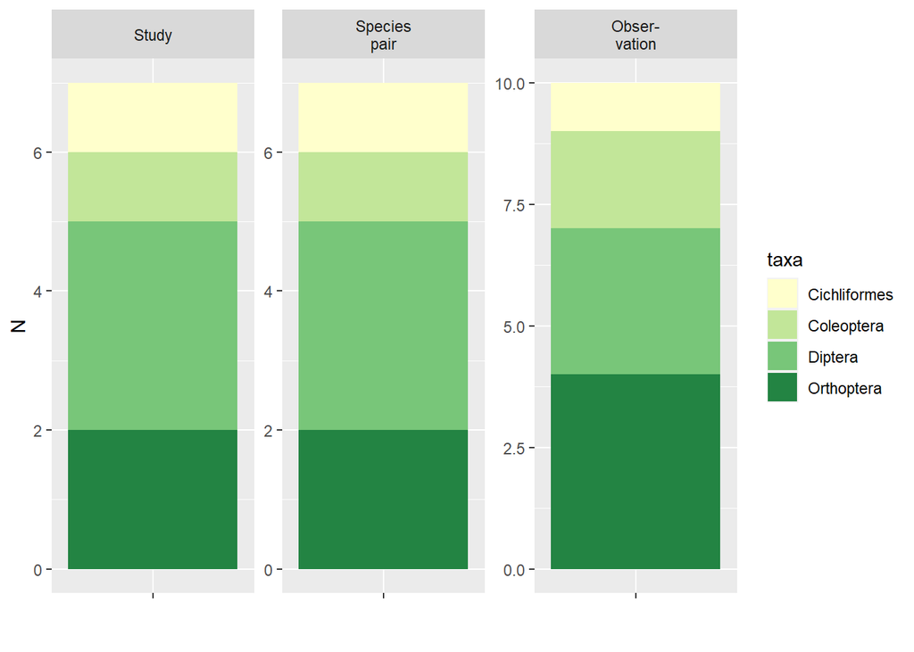

```r
### Plot ###
ggplot(
  # Make tidy summary data
  summary %>%
  gather(key = metrics, value = N, -c(taxa)) %>%
  # Order metrics
  within(
    metrics <- ordered(
      metrics,
      levels = c("Study", "Species pair", "Obser- vation")
      )
    ),
  aes(x = "", y = N, fill = taxa)) +
  geom_bar(width = 1, stat = "identity") +
  scale_fill_brewer(palette = "YlGn") +
  facet_wrap(
    scale = "free", "metrics",
    # strip text into two lines
    labeller = label_wrap_gen(width = 8)
    ) +
  xlab("")
```

# Meta-regression for phenotypic variation

We quantified relative phenotypic variability of hybrids and the parent with large variability (*spLL<sub>V</sub>*) to the parent with small variability (*spSS<sub>V</sub>*), by using [lnCVR](https://besjournals.onlinelibrary.wiley.com/doi/full/10.1111/2041-210X.12309). We controlled mean-variance relationship by using Coefficient of Variation (CV) as the proxy of phenotypic variability.

We then regressed relative phenotypic variability of hybrids (arrows 2&3 in Fig.1b of [Atsumi et al](https://ecoevorxiv.org/kt3ud/)) by phenotypic variability of parent (arrow 1 - to controll the additive inheritance for phenotypic variability, `spL.variability`) and estimated number of QTLs for the focal traits (`N.QTL`).

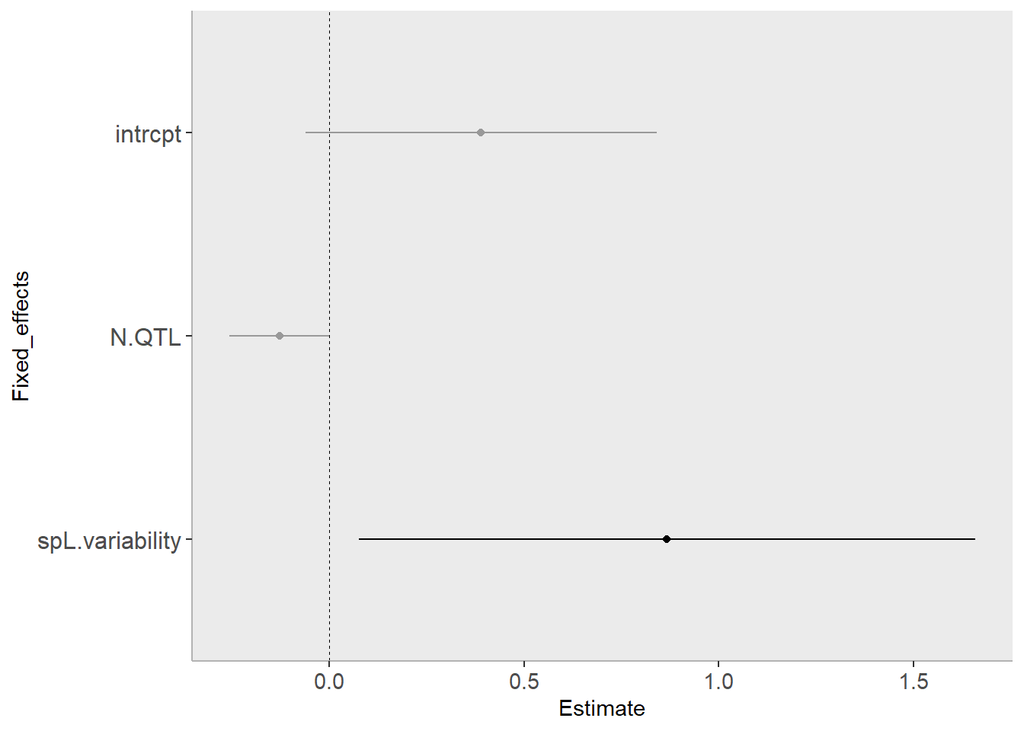

```r
#+++++++++++++++++++++++++++++++++++++++++++++++++++++++++++++++++++++++++++++++#
# Align parental species by phenotypic variability size
#+++++++++++++++++++++++++++++++++++++++++++++++++++++++++++++++++++++++++++++++#

#+++++++++++++++++++++++++++++++++++++++++++++++++#
# sp1 >= sp2 in phenotypic variation (CV)
#+++++++++++++++++++++++++++++++++++++++++++++++++#
# extract
sp1sp2.var <- original.dat %>%
  filter(SD.sp1/Mn.sp1 >= SD.sp2/Mn.sp2) # filtering according to CV of parentals
# change column name from sp1 or sp2 -> spL or spS
names(sp1sp2.var) <- gsub("1", "L", names(sp1sp2.var))
names(sp1sp2.var) <- gsub("2", "S", names(sp1sp2.var))

#+++++++++++++++++++++++++++++++++++++++++++++++++#
# sp1 < sp2 in phenotypic variation (CV)
#+++++++++++++++++++++++++++++++++++++++++++++++++#
# extract
sp2sp1.var <- original.dat %>%
  filter(SD.sp1/Mn.sp1 < SD.sp2/Mn.sp2)
# change column name from sp1 or sp2 -> spS or spL
names(sp2sp1.var) <- gsub("1", "S", names(sp2sp1.var))
names(sp2sp1.var) <- gsub("2", "L", names(sp2sp1.var))



#+++++++++++++++++++++++++++++++++++++++++++++++++++++++++++++++++++++++++++++++#
# Effect size calculation | lnCVR
#+++++++++++++++++++++++++++++++++++++++++++++++++++++++++++++++++++++++++++++++#

dat <- bind_rows(sp1sp2.var, sp2sp1.var)

# Order by taxon
dat$taxa <- ordered(
  dat$taxa,
  levels = c("Neuroptera", "Coleoptera", "Diptera", "Lepidoptera", "Orthoptera", "Aves", "Rodentia", "Anura", "Cichliformes")
  )

for (i in c("hybLS", "hybSL", "spL")) { # identify type of hybrids
  for (h in c("spS")) { # identify type of parentals
    assign(
      paste(i, h, sep = "_"),
        escalc(
          measure = "CVR",
          # N of hybrids
          n1i = dat[, paste("N", i, sep = ".")],
          # N of parentals
          n2i = dat[, paste("N", h, sep = ".")],
          # Mean of hybrids
          m1i = dat[, paste("Mn", i, sep = ".")],
          # Mean of parentals
          m2i = dat[, paste("Mn", h, sep = ".")],
          # SD of hybrids
          sd1i = dat[, paste("SD", i, sep = ".")],
          # SD of parentals
          sd2i = dat[, paste("SD", h, sep = ".")],
          data = dat
          ) %>%
          mutate(cross = i)
    )
  }
}

# Combine all ES datasets
CV.dif <- bind_rows(
  hybLS_spS, hybSL_spS
  ) %>%
  left_join(
    spL_spS %>%
      dplyr::select("ES.ID", "yi") %>%
      rename(spL.variability = yi)
  ) %>%
  drop_na(yi) %>%
  arrange(ES.ID) %>%
  left_join(., dat)


# Regress by lnRR of phenotypic difference between parentals
model <- rma.mv(
  yi = yi, V = vi,
  data = CV.dif, method = "REML",
  random = list(~1 | spL.name, ~1 | ES.ID),
  mods = ~ N.QTL + spL.variability
  )

### Output result ###
reg <- tibble(
    'Fixed_effects' = row.names(model$beta),
    'Estimate' = model$beta, # regression: estimate
    'LowerCI' = model$ci.lb, # regression: 95ci,
    'UpperCI'  = model$ci.ub, # regression: 95ci
    'P'        = model$pval
    )  %>%
    as.data.frame() %>%
    mutate(significance = ifelse(P < 0.05, "*", "")) %>%
  mutate_at("Fixed_effects", as.factor)

ggplot(reg, aes(y = Estimate, x = Fixed_effects)) +
  geom_errorbar(
    aes(ymin = LowerCI, ymax = UpperCI, colour=significance),
    width=.0001
    ) +
  # Color of plots and errorbars
  scale_colour_manual(values = c("grey60", "black")) +
  geom_point(size = 1.5, aes(colour = significance)) +
  scale_fill_manual(values = c("grey60", "black")) +
  scale_x_discrete(limits = rev(reg$Fixed_effects))+ # reverse x-axis
  geom_hline(yintercept = 0, linetype="dashed", size = 0.3) +
  coord_flip() +
  theme(
    panel.grid = element_blank(),
    legend.position = "none",
    panel.border=element_blank(),
    axis.text.x = element_text(size = 11),
    axis.text.y = element_text(size = 12),
    axis.line=element_line(colour = "grey70")
    )
```

The result implies negative relationship between F1 phenotypic variability and QTL counts.

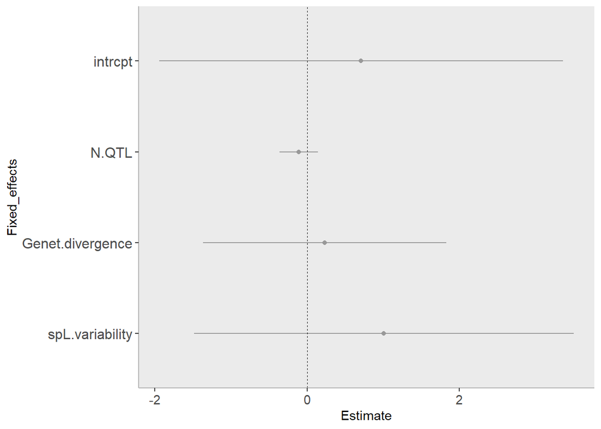

```r
# Regress by lnRR of phenotypic difference between parentals
model <- rma.mv(
  yi = yi, V = vi,
  data = CV.dif, method = "REML",
  random = list(~1 | spL.name, ~1 | ES.ID),
  mods = ~ N.QTL + Genet.divergence + spL.variability
  )

### Output result ###
reg <- tibble(
    'Fixed_effects' = row.names(model$beta),
    'Estimate' = model$beta, # regression: estimate
    'LowerCI' = model$ci.lb, # regression: 95ci,
    'UpperCI'  = model$ci.ub, # regression: 95ci
    'P'        = model$pval
    )  %>%
    as.data.frame() %>%
    mutate(significance = ifelse(P < 0.05, "*", "")) %>%
  mutate_at("Fixed_effects", as.factor)

ggplot(reg, aes(y = Estimate, x = Fixed_effects)) +
  geom_errorbar(
    aes(ymin = LowerCI, ymax = UpperCI, colour=significance),
    width=.0001
    ) +
  # Color of plots and errorbars
  scale_colour_manual(values = c("grey60", "black")) +
  geom_point(size = 1.5, aes(colour = significance)) +
  scale_fill_manual(values = c("grey60", "black")) +
  scale_x_discrete(limits = rev(reg$Fixed_effects))+ # reverse x-axis
  geom_hline(yintercept = 0, linetype="dashed", size = 0.3) +
  coord_flip() +
  theme(
    panel.grid = element_blank(),
    legend.position = "none",
    panel.border=element_blank(),
    axis.text.x = element_text(size = 11),
    axis.text.y = element_text(size = 12),
    axis.line=element_line(colour = "grey70")
    )
```

After genetic divergence between parents was included (reduce 2 data points), sign of the effect of QTL counts remained negative, but became weaker.